# Prediction from IoT Devices

Riccardo Conteduca

6/7/2020

## Background

Using devices such as Jawbone Up, Nike FuelBand, and Fitbit it is now possible to collect a large amount of data about personal activity relatively inexpensively. These type of devices are part of the quantified self movement – a group of enthusiasts who take measurements about themselves regularly to improve their health, to find patterns in their behavior, or because they are tech geeks. One thing that people regularly do is quantify how much of a particular activity they do, but they rarely quantify how well they do it. In this project, your goal will be to use data from accelerometers on the belt, forearm, arm, and dumbell of 6 participants. They were asked to perform barbell lifts correctly and incorrectly in 5 different ways. More information is available from the website here: http://web.archive.org/web/20161224072740/http:/groupware.les.inf.puc-rio.br/har (see the section on the Weight Lifting Exercise Dataset).

Setting the random seed for reproducibility

```r
set.seed(1023)
```

## Data cleaning

We can start by looking at the information provided from test and training data and start cleaning before we start creating our models.

```r
unique(pml_training$classe)
```

```
## [1] "A" "B" "C" "D" "E"
```

```r
unique(pml_training$user_name)
```

```
## [1] "carlitos" "pedro"    "adelmo"   "charles"  "eurico"   "jeremy"
```

the sapply performed on the columns shown below removes the messy information we want to remove (There are a number of NA and DIV/0 Values that are not going to be useful in our models). We can assume that all NA values can be safely removed in order to clean the training data, we also remove information that seems not important, or unnecessary raw information that is present. The histogram shows the number of ‘classe’ variables we have for our training data

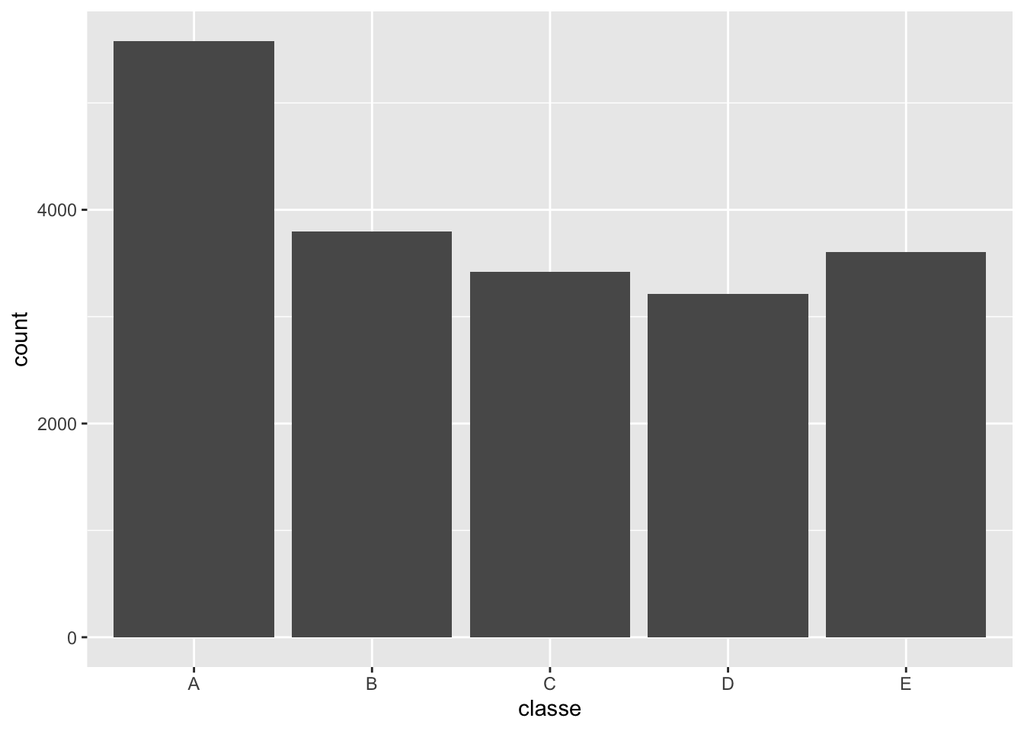

```r
dat <- pml_training
dat <- dat[,sapply(dat,function(x) !any(is.na(x)))]
user <- dat$user_name
rest <- dat[,8:60]
final_training_data <- cbind(user,rest)
g2 <-  ggplot(final_training_data, aes(x = classe)) + geom_histogram(stat='count')
g2
```

We need to do the same thing for the test data, the procedure is exactly the same.

```r
testing <- pml_testing
testing <- testing[,sapply(testing,function(x) !any(is.na(x)))]
user <-  testing$user_name
b <- testing[,8:60]
final_testing_data <- cbind(user,b)
```

```r
part <- createDataPartition(final_training_data$classe,p = 0.8, list = FALSE)
final_training_data = final_training_data[part,]
final_evaluation_data = final_training_data[-part,]
train_control<- trainControl(method="cv", number=5, savePredictions = TRUE)
```

## Multinomial logistic regression

The first model used is the multinomial logistic regression algorithm available in the caret package. Briefly, multinomial logistic regression is a classification method that generalizes logistic regression to multiclass problems. These are problems with more than two possible discrete outcomes. Multinomial logistic regression is used to model nominal outcome variables, in which the log odds of the outcomes are modeled as a linear combination of the predictor variables.

```r
multi.logistic <- train(classe ~ ., data=final_training_data, method="multinom",trControl=train_control, trace = F)
#the model information and confusion matrix is shown below for the in-sample accuracy
multi.logistic$metric
```

```
## [1] "Accuracy"
```

```r
#In sample
confusionMatrix(multi.logistic)
```

```
## Cross-Validated (5 fold) Confusion Matrix
##
## (entries are percentual average cell counts across resamples)
##
##           Reference
## Prediction    A    B    C    D    E
##          A 24.1  3.5  3.1  1.9  1.6
##          B  1.0 10.1  1.4  0.7  2.2
##          C  0.8  1.9 10.3  2.0  1.6
##          D  1.9  1.7  1.5 11.1  2.7
##          E  0.6  2.1  1.2  0.7 10.3
##
##  Accuracy (average) : 0.6593
```

```r
#The predictions and out-of-sample accuracy is shown below
pred.multi.logistic <- predict(multi.logistic,final_evaluation_data)
factor.evaluation <- as.factor(final_evaluation_data$classe)
#Out of sample
confusionMatrix(pred.multi.logistic, factor.evaluation)
```

```
## Confusion Matrix and Statistics
##
##           Reference
## Prediction   A   B   C   D   E
##          A 693  60  70  57  42
##          B  64 342  63  33  81
##          C  67  79 349  50  33
##          D  46  56  50 317  62
##          E   4  81  38  46 362
##
## Overall Statistics
##
##                Accuracy : 0.656
##                  95% CI : (0.6391, 0.6726)
##     No Information Rate : 0.2779
##     P-Value [Acc > NIR] : < 2.2e-16
##
##                   Kappa : 0.5649
##
##  Mcnemar's Test P-Value : 4.524e-06
##
## Statistics by Class:
##
##                      Class: A Class: B Class: C Class: D Class: E
## Sensitivity            0.7929   0.5534   0.6123   0.6302   0.6241
## Specificity            0.8992   0.9046   0.9111   0.9190   0.9341
## Pos Pred Value         0.7516   0.5866   0.6038   0.5970   0.6817
## Neg Pred Value         0.9186   0.8923   0.9139   0.9288   0.9166
## Prevalence             0.2779   0.1965   0.1812   0.1599   0.1844
## Detection Rate         0.2203   0.1087   0.1110   0.1008   0.1151
## Detection Prevalence   0.2932   0.1854   0.1838   0.1688   0.1688
## Balanced Accuracy      0.8460   0.7290   0.7617   0.7746   0.7791
```

As we can see the accuracy isn’t great. Nonetheless, it’s a great starting point to have.

## Recursive partitioning algorithm

Rpart is the second model that was tested on the data. Briefly, Recursive partitioning is a statistical method used for multivariable analysis. The algorithm creates a decision tree used to correctly classify members of the population by splitting it into sub-populations based on several dichotomous independent variables.

```r
decision.tree <- train(classe ~ ., data=final_training_data, method = 'rpart', trControl = train_control)

decision.tree
```

```
## CART
##
## 15699 samples
##    53 predictor
##     5 classes: 'A', 'B', 'C', 'D', 'E'
##
## No pre-processing
## Resampling: Cross-Validated (5 fold)
## Summary of sample sizes: 12560, 12558, 12560, 12558, 12560
## Resampling results across tuning parameters:
##
##   cp          Accuracy   Kappa
##   0.02585670  0.5489531  0.42035088
##   0.02845275  0.5434772  0.41303746
##   0.11553182  0.3169608  0.04962787
##
## Accuracy was used to select the optimal model using the largest value.
## The final value used for the model was cp = 0.0258567.
```

```r
#In sample
confusionMatrix(decision.tree)
```

```
## Cross-Validated (5 fold) Confusion Matrix
##
## (entries are percentual average cell counts across resamples)
##
##           Reference
## Prediction    A    B    C    D    E
##          A 22.4  6.1  5.2  4.8  1.6
##          B  1.8  7.7  1.0  2.2  2.9
##          C  3.5  3.2 10.3  3.7  3.2
##          D  0.6  1.7  0.7  5.5  1.6
##          E  0.2  0.7  0.2  0.3  9.0
##
##  Accuracy (average) : 0.549
```

```r
#Out of sample
pred.decision.tree <- predict(decision.tree,final_evaluation_data)
confusionMatrix(pred.decision.tree, factor.evaluation)
```

```
## Confusion Matrix and Statistics
##
##           Reference
## Prediction   A   B   C   D   E
##          A 552 110  14  32  12
##          B 156 407  64 212 180
##          C 151  96 476 130 119
##          D  14   5  16 129   9
##          E   1   0   0   0 260
##
## Overall Statistics
##
##                Accuracy : 0.58
##                  95% CI : (0.5625, 0.5973)
##     No Information Rate : 0.2779
##     P-Value [Acc > NIR] : < 2.2e-16
##
##                   Kappa : 0.4701
##
##  Mcnemar's Test P-Value : < 2.2e-16
##
## Statistics by Class:
##
##                      Class: A Class: B Class: C Class: D Class: E
## Sensitivity            0.6316   0.6586   0.8351  0.25646  0.44828
## Specificity            0.9260   0.7578   0.8074  0.98335  0.99961
## Pos Pred Value         0.7667   0.3994   0.4897  0.74566  0.99617
## Neg Pred Value         0.8672   0.9008   0.9567  0.87416  0.88904
## Prevalence             0.2779   0.1965   0.1812  0.15994  0.18442
## Detection Rate         0.1755   0.1294   0.1514  0.04102  0.08267
## Detection Prevalence   0.2289   0.3240   0.3091  0.05501  0.08299
## Balanced Accuracy      0.7788   0.7082   0.8212  0.61990  0.72394
```

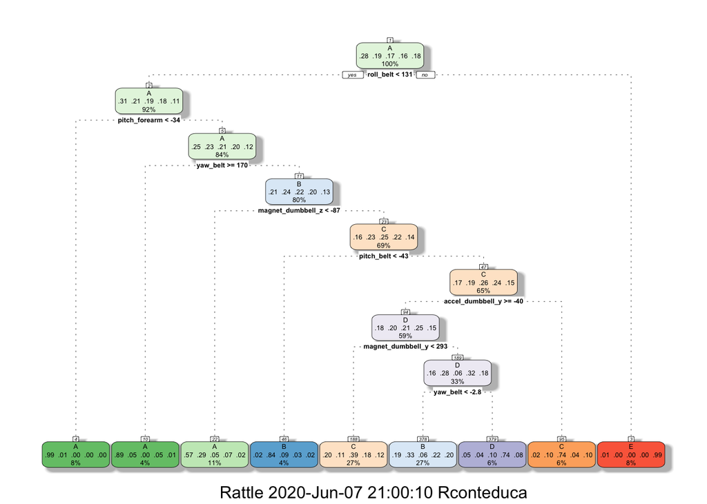

```r
fancyRpartPlot(decision.tree$finalModel)
```

As we can see, the accuracy is even worst than the previous model. Hopefully, the next model will yield better results.

## Random Forest

Briefly, Random forests are an ensemble learning method for classification, regression and other tasks that operate by constructing a multitude of decision trees at training time and outputting the class that is the mode of the classes (classification) or mean prediction (regression) of the individual trees

The final model used is Random Forest, which is well-known for its high accuracy at the expense of interpretability.

```r
rf.model <- train(classe ~ ., data=final_training_data, method="rf",
                  trControl=train_control)

confusionMatrix(rf.model)
```

```
## Cross-Validated (5 fold) Confusion Matrix
##
## (entries are percentual average cell counts across resamples)
##
##           Reference
## Prediction    A    B    C    D    E
##          A 28.4  0.2  0.0  0.0  0.0
##          B  0.0 19.1  0.1  0.0  0.0
##          C  0.0  0.1 17.3  0.2  0.0
##          D  0.0  0.0  0.1 16.1  0.0
##          E  0.0  0.0  0.0  0.0 18.3
##
##  Accuracy (average) : 0.9924
```

The in-sample accuracy is incredibly high (an average of 99.24%), we will now check with the evaluation set

```r
predictions <- predict(rf.model,final_evaluation_data)
a <- as.factor(final_evaluation_data$classe)
confusionMatrix(predictions,a)
```

```
## Confusion Matrix and Statistics
##
##           Reference
## Prediction   A   B   C   D   E
##          A 874   0   0   0   0
##          B   0 618   0   0   0
##          C   0   0 570   0   0
##          D   0   0   0 503   0
##          E   0   0   0   0 580
##
## Overall Statistics
##
##                Accuracy : 1
##                  95% CI : (0.9988, 1)
##     No Information Rate : 0.2779
##     P-Value [Acc > NIR] : < 2.2e-16
##
##                   Kappa : 1
##
##  Mcnemar's Test P-Value : NA
##
## Statistics by Class:
##
##                      Class: A Class: B Class: C Class: D Class: E
## Sensitivity            1.0000   1.0000   1.0000   1.0000   1.0000
## Specificity            1.0000   1.0000   1.0000   1.0000   1.0000
## Pos Pred Value         1.0000   1.0000   1.0000   1.0000   1.0000
## Neg Pred Value         1.0000   1.0000   1.0000   1.0000   1.0000
## Prevalence             0.2779   0.1965   0.1812   0.1599   0.1844
## Detection Rate         0.2779   0.1965   0.1812   0.1599   0.1844
## Detection Prevalence   0.2779   0.1965   0.1812   0.1599   0.1844
## Balanced Accuracy      1.0000   1.0000   1.0000   1.0000   1.0000
```

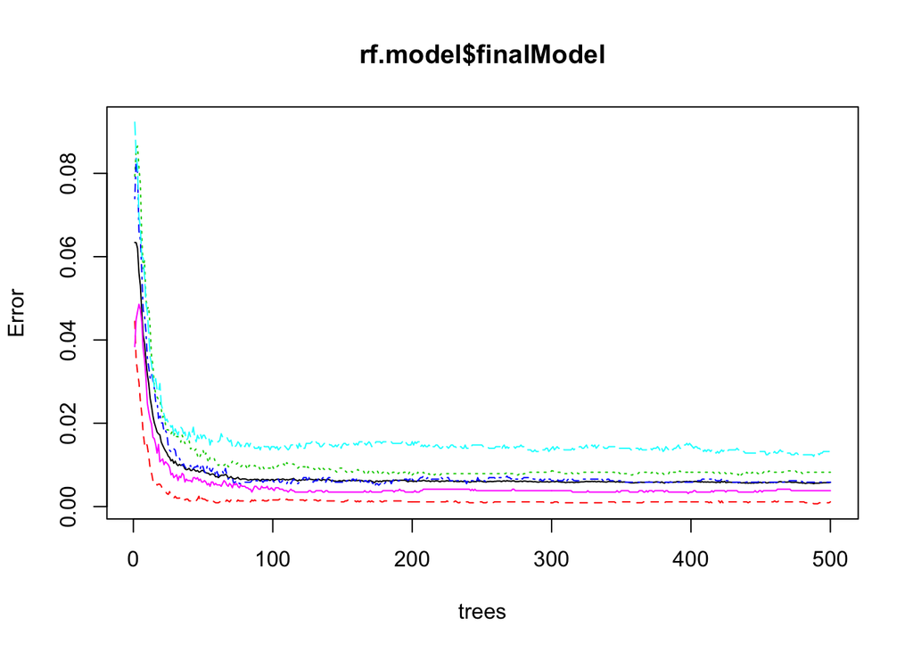

```r
plot(rf.model$finalModel)
```

```r
predictions_test <- predict(rf.model, final_testing_data)
predictions_test
```

```
##  [1] B A B A A E D B A A B C B A E E A B B B
## Levels: A B C D E
```

The data for this project come from this source: http://web.archive.org/web/20161224072740/http:/groupware.les.inf.puc-rio.br/har. If you use the document you create for this class for any purpose please cite them as they have been very generous in allowing their data to be used for this kind of assignment.